# Identify_Customer_Segments

### Prerequsite - Upgrade Scikit Learn

The current workspace has scikit-learn v0.19.1 installed. However, you can upgrade scikit-learn to 0.24.x. and use this [OneHotEncoder](https://scikit-learn.org/0.21/modules/generated/sklearn.preprocessing.OneHotEncoder.html) library.

```python
# import sklearn
# print('The scikit-learn version is {}.'.format(sklearn.__version__))
```

```python
# import os
# os.environ['PATH'] = f"{os.environ['PATH']}:/root/.local/bin"
```

Restart the Kernel.

```python
!python -m pip install --upgrade scikit-learn
import sklearn
print('The scikit-learn version is {}.'.format(sklearn.__version__))
```

```
The scikit-learn version is 0.24.2.
```

```python
# Now you can import and use OneHotEncoder
from sklearn.preprocessing import OneHotEncoder
# your code goes here
```

```python
# # Similarly, should you need any other package, they can install it as:
# !python -m pip install 'tensorflow-tensorboard<0.2.0,>=0.1.0'
```

# Project: Identify Customer Segments

In this project, you will apply unsupervised learning techniques to identify segments of the population that form the core customer base for a mail-order sales company in Germany. These segments can then be used to direct marketing campaigns towards audiences that will have the highest expected rate of returns. The data that you will use has been provided by our partners at Bertelsmann Arvato Analytics, and represents a real-life data science task.

This notebook will help you complete this task by providing a framework within which you will perform your analysis steps. In each step of the project, you will see some text describing the subtask that you will perform, followed by one or more code cells for you to complete your work. **Feel free to add additional code and markdown cells as you go along so that you can explore everything in precise chunks.** The code cells provided in the base template will outline only the major tasks, and will usually not be enough to cover all of the minor tasks that comprise it.

It should be noted that while there will be precise guidelines on how you should handle certain tasks in the project, there will also be places where an exact specification is not provided. **There will be times in the project where you will need to make and justify your own decisions on how to treat the data.** These are places where there may not be only one way to handle the data. In real-life tasks, there may be many valid ways to approach an analysis task. One of the most important things you can do is clearly document your approach so that other scientists can understand the decisions you've made.

At the end of most sections, there will be a Markdown cell labeled **Discussion**. In these cells, you will report your findings for the completed section, as well as document the decisions that you made in your approach to each subtask. **Your project will be evaluated not just on the code used to complete the tasks outlined, but also your communication about your observations and conclusions at each stage.**

```python
# import libraries here; add more as necessary
import numpy as np
import pandas as pd
import matplotlib.pyplot as plt
import seaborn as sns
import ast
import re
from sklearn.preprocessing import OneHotEncoder, LabelEncoder, StandardScaler
from sklearn.impute import SimpleImputer
from IPython.display import Markdown, display
from sklearn.decomposition import PCA
from sklearn.cluster import KMeans
from mpl_toolkits.mplot3d import Axes3D

# magic word for producing visualizations in notebook
%matplotlib inline

'''
Import note: The classroom currently uses sklearn version 0.19.
If you need to use an imputer, it is available in sklearn.preprocessing.Imputer,
instead of sklearn.impute as in newer versions of sklearn.
'''
pd.options.display.max_rows = None
pd.options.display.max_columns = None
```

### Step 0: Load the Data

There are four files associated with this project (not including this one):

- `Udacity_AZDIAS_Subset.csv`: Demographics data for the general population of Germany; 891211 persons (rows) x 85 features (columns).
- `Udacity_CUSTOMERS_Subset.csv`: Demographics data for customers of a mail-order company; 191652 persons (rows) x 85 features (columns).
- `Data_Dictionary.md`: Detailed information file about the features in the provided datasets.
- `AZDIAS_Feature_Summary.csv`: Summary of feature attributes for demographics data; 85 features (rows) x 4 columns

Each row of the demographics files represents a single person, but also includes information outside of individuals, including information about their household, building, and neighborhood. You will use this information to cluster the general population into groups with similar demographic properties. Then, you will see how the people in the customers dataset fit into those created clusters. The hope here is that certain clusters are over-represented in the customers data, as compared to the general population; those over-represented clusters will be assumed to be part of the core userbase. This information can then be used for further applications, such as targeting for a marketing campaign.

To start off with, load in the demographics data for the general population into a pandas DataFrame, and do the same for the feature attributes summary. Note for all of the `.csv` data files in this project: they're semicolon (`;`) delimited, so you'll need an additional argument in your [`read_csv()`](https://pandas.pydata.org/pandas-docs/stable/generated/pandas.read_csv.html) call to read in the data properly. Also, considering the size of the main dataset, it may take some time for it to load completely.

Once the dataset is loaded, it's recommended that you take a little bit of time just browsing the general structure of the dataset and feature summary file. You'll be getting deep into the innards of the cleaning in the first major step of the project, so gaining some general familiarity can help you get your bearings.

#### Load the Datasets

```python
# Load in the general demographics data.
genDemo = pd.read_csv("Udacity_AZDIAS_Subset.csv",
                      delimiter=";")

# Load in the feature summary file.
featSumm = pd.read_csv("AZDIAS_Feature_Summary.csv",
                       delimiter=";")
```

#### Check that the number of rows match what we expect for each of these files

```python
print(genDemo.shape)
```

```
(891221, 85)
```

```python
print(featSumm.shape)
```

```
(85, 4)
```

#### Let's take a deeper look at the genDemo dataframe

```python
genDemo.head()
```

|  | AGER_TYP | ALTERSKATEGORIE_GROB | ANREDE_KZ | CJT_GESAMTTYP | FINANZ_MINIMALIST | FINANZ_SPARER | FINANZ_VORSORGER | FINANZ_ANLEGER | FINANZ_UNAUFFAELLIGER | FINANZ_HAUSBAUER | FINANZTYP | GEBURTSJAHR | GFK_URLAUBERTYP | GREEN_AVANTGARDE | HEALTH_TYP | LP_LEBENSPHASE_FEIN | LP_LEBENSPHASE_GROB | LP_FAMILIE_FEIN | LP_FAMILIE_GROB | LP_STATUS_FEIN | LP_STATUS_GROB | NATIONALITAET_KZ | PRAEGENDE_JUGENDJAHRE | RETOURTYP_BK_S | SEMIO_SOZ | SEMIO_FAM | SEMIO_REL | SEMIO_MAT | SEMIO_VERT | … |
| --- | --- | --- | --- | --- | --- | --- | --- | --- | --- | --- | --- | --- | --- | --- | --- | --- | --- | --- | --- | --- | --- | --- | --- | --- | --- | --- | --- | --- | --- | --- |
| 0 | -1 | 2 | 1 | 2.0 | 3 | 4 | 3 | 5 | 5 | 3 | 4 | 0 | 10.0 | 0 | -1 | 15.0 | 4.0 | 2.0 | 2.0 | 1.0 | 1.0 | 0 | 0 | 5.0 | 2 | 6 | 7 | 5 | 1 | … |
| 1 | -1 | 1 | 2 | 5.0 | 1 | 5 | 2 | 5 | 4 | 5 | 1 | 1996 | 10.0 | 0 | 3 | 21.0 | 6.0 | 5.0 | 3.0 | 2.0 | 1.0 | 1 | 14 | 1.0 | 5 | 4 | 4 | 3 | 1 | … |
| 2 | -1 | 3 | 2 | 3.0 | 1 | 4 | 1 | 2 | 3 | 5 | 1 | 1979 | 10.0 | 1 | 3 | 3.0 | 1.0 | 1.0 | 1.0 | 3.0 | 2.0 | 1 | 15 | 3.0 | 4 | 1 | 3 | 3 | 4 | … |
| 3 | 2 | 4 | 2 | 2.0 | 4 | 2 | 5 | 2 | 1 | 2 | 6 | 1957 | 1.0 | 0 | 2 | 0.0 | 0.0 | 0.0 | 0.0 | 9.0 | 4.0 | 1 | 8 | 2.0 | 5 | 1 | 2 | 1 | 4 | … |
| 4 | -1 | 3 | 1 | 5.0 | 4 | 3 | 4 | 1 | 3 | 2 | 5 | 1963 | 5.0 | 0 | 3 | 32.0 | 10.0 | 10.0 | 5.0 | 3.0 | 2.0 | 1 | 8 | 5.0 | 6 | 4 | 4 | 2 | 7 | … |

Looks like some of the columns have "nan" used to indicate that values are missing altogether. There is a also a column called "GEBURTSJAHR" that appears to have some year information but the first row has a value of 0 which seems incorrect.

```python
genDemo.describe()
```

|  | AGER_TYP | ALTERSKATEGORIE_GROB | ANREDE_KZ | CJT_GESAMTTYP | FINANZ_MINIMALIST | FINANZ_SPARER | FINANZ_VORSORGER | FINANZ_ANLEGER | FINANZ_UNAUFFAELLIGER | FINANZ_HAUSBAUER | FINANZTYP | GEBURTSJAHR | GFK_URLAUBERTYP | GREEN_AVANTGARDE | HEALTH_TYP | LP_LEBENSPHASE_FEIN | LP_LEBENSPHASE_GROB | LP_FAMILIE_FEIN | LP_FAMILIE_GROB | LP_STATUS_FEIN | LP_STATUS_GROB | NATIONALITAET_KZ | PRAEGENDE_JUGENDJAHRE | RETOURTYP_BK_S | SEMIO_SOZ | SEMIO_FAM | SEMIO_REL | SEMIO_MAT | SEMIO_VERT | … |
| --- | --- | --- | --- | --- | --- | --- | --- | --- | --- | --- | --- | --- | --- | --- | --- | --- | --- | --- | --- | --- | --- | --- | --- | --- | --- | --- | --- | --- | --- | --- |
| count | 891221.000000 | 891221.000000 | 891221.000000 | 886367.000000 | 891221.000000 | 891221.000000 | 891221.000000 | 891221.000000 | 891221.000000 | 891221.000000 | 891221.000000 | 891221.000000 | 886367.000000 | 891221.000000 | 891221.000000 | 886367.000000 | 886367.000000 | 886367.000000 | 886367.000000 | 886367.000000 | 886367.000000 | 891221.000000 | 891221.000000 | 886367.000000 | 891221.000000 | 891221.000000 | 891221.000000 | 891221.000000 | 891221.000000 | … |
| mean | -0.358435 | 2.777398 | 1.522098 | 3.632838 | 3.074528 | 2.821039 | 3.401106 | 3.033328 | 2.874167 | 3.075121 | 3.790586 | 1101.178533 | 7.350304 | 0.196612 | 1.792102 | 14.622637 | 4.453621 | 3.599574 | 2.185966 | 4.791151 | 2.432575 | 1.026827 | 8.154346 | 3.419630 | 3.945860 | 4.272729 | 4.240609 | 4.001597 | 4.023709 | … |
| std | 1.198724 | 1.068775 | 0.499512 | 1.595021 | 1.321055 | 1.464749 | 1.322134 | 1.529603 | 1.486731 | 1.353248 | 1.987876 | 976.583551 | 3.525723 | 0.397437 | 1.269062 | 12.616883 | 3.855639 | 3.926486 | 1.756537 | 3.425305 | 1.474315 | 0.586634 | 4.844532 | 1.417741 | 1.946564 | 1.915885 | 2.007373 | 1.857540 | 2.077746 | … |
| min | -1.000000 | 1.000000 | 1.000000 | 1.000000 | 1.000000 | 1.000000 | 1.000000 | 1.000000 | 1.000000 | 1.000000 | 1.000000 | 0.000000 | 1.000000 | 0.000000 | -1.000000 | 0.000000 | 0.000000 | 0.000000 | 0.000000 | 1.000000 | 1.000000 | 0.000000 | 0.000000 | 1.000000 | 1.000000 | 1.000000 | 1.000000 | 1.000000 | 1.000000 | … |
| 25% | -1.000000 | 2.000000 | 1.000000 | 2.000000 | 2.000000 | 1.000000 | 3.000000 | 2.000000 | 2.000000 | 2.000000 | 2.000000 | 0.000000 | 5.000000 | 0.000000 | 1.000000 | 4.000000 | 1.000000 | 1.000000 | 1.000000 | 2.000000 | 1.000000 | 1.000000 | 5.000000 | 2.000000 | 2.000000 | 3.000000 | 3.000000 | 2.000000 | 2.000000 | … |
| 50% | -1.000000 | 3.000000 | 2.000000 | 4.000000 | 3.000000 | 3.000000 | 3.000000 | 3.000000 | 3.000000 | 3.000000 | 4.000000 | 1943.000000 | 8.000000 | 0.000000 | 2.000000 | 11.000000 | 3.000000 | 1.000000 | 1.000000 | 4.000000 | 2.000000 | 1.000000 | 8.000000 | 3.000000 | 4.000000 | 4.000000 | 4.000000 | 4.000000 | 4.000000 | … |
| 75% | -1.000000 | 4.000000 | 2.000000 | 5.000000 | 4.000000 | 4.000000 | 5.000000 | 5.000000 | 4.000000 | 4.000000 | 6.000000 | 1970.000000 | 10.000000 | 0.000000 | 3.000000 | 27.000000 | 8.000000 | 8.000000 | 4.000000 | 9.000000 | 4.000000 | 1.000000 | 14.000000 | 5.000000 | 6.000000 | 6.000000 | 6.000000 | 5.000000 | 6.000000 | … |
| max | 3.000000 | 9.000000 | 2.000000 | 6.000000 | 5.000000 | 5.000000 | 5.000000 | 5.000000 | 5.000000 | 5.000000 | 6.000000 | 2017.000000 | 12.000000 | 1.000000 | 3.000000 | 40.000000 | 12.000000 | 11.000000 | 5.000000 | 10.000000 | 5.000000 | 3.000000 | 15.000000 | 5.000000 | 7.000000 | 7.000000 | 7.000000 | 7.000000 | 7.000000 | … |

```python
genDemo.isna().sum()
```

```
AGER_TYP                      0
ALTERSKATEGORIE_GROB          0
ANREDE_KZ                     0
CJT_GESAMTTYP              4854
FINANZ_MINIMALIST             0
FINANZ_SPARER                 0
FINANZ_VORSORGER              0
FINANZ_ANLEGER                0
FINANZ_UNAUFFAELLIGER         0
FINANZ_HAUSBAUER              0
FINANZTYP                     0
GEBURTSJAHR                   0
GFK_URLAUBERTYP            4854
GREEN_AVANTGARDE              0
HEALTH_TYP                    0
LP_LEBENSPHASE_FEIN        4854
LP_LEBENSPHASE_GROB        4854
LP_FAMILIE_FEIN            4854
LP_FAMILIE_GROB            4854
LP_STATUS_FEIN             4854
LP_STATUS_GROB             4854
NATIONALITAET_KZ              0
PRAEGENDE_JUGENDJAHRE         0
RETOURTYP_BK_S             4854
SEMIO_SOZ                     0
SEMIO_FAM                     0
SEMIO_REL                     0
SEMIO_MAT                     0
SEMIO_VERT                    0
SEMIO_LUST                    0
SEMIO_ERL                     0
SEMIO_KULT                    0
SEMIO_RAT                     0
SEMIO_KRIT                    0
SEMIO_DOM                     0
SEMIO_KAEM                    0
SEMIO_PFLICHT                 0
SEMIO_TRADV                   0
SHOPPER_TYP                   0
SOHO_KZ                   73499
```

[output cut: 31 more lines]

```
MOBI_REGIO               133324
ONLINE_AFFINITAET          4854
REGIOTYP                 121196
KBA13_ANZAHL_PKW         105800
PLZ8_ANTG1               116515
PLZ8_ANTG2               116515
PLZ8_ANTG3               116515
PLZ8_ANTG4               116515
PLZ8_BAUMAX              116515
PLZ8_HHZ                 116515
PLZ8_GBZ                 116515
ARBEIT                    97216
ORTSGR_KLS9               97216
RELAT_AB                  97216
dtype: int64
```

There are columns like "KK_KUNDENTYP" where nearly half of the rows are nan, this seems like a column that we could just blindly eliminate. For other columns we will need to understand if they can be removed blindly or if we need to impute values for missing information.

#### Let's take a deeper look at the featSumm dataframe

```python
featSumm.head()
```

|  | attribute | information_level | type | missing_or_unknown |
| --- | --- | --- | --- | --- |
| 0 | AGER_TYP | person | categorical | [-1,0] |
| 1 | ALTERSKATEGORIE_GROB | person | ordinal | [-1,0,9] |
| 2 | ANREDE_KZ | person | categorical | [-1,0] |
| 3 | CJT_GESAMTTYP | person | categorical | [0] |
| 4 | FINANZ_MINIMALIST | person | ordinal | [-1] |

This dataframe looks to tell us, beyond just nan values, what a missing or unknown value for that column would be encoded as. It also gives us the type of this column (categorical, ordinal, numeric, etc)

> **Tip**: Add additional cells to keep everything in reasonably-sized chunks! Keyboard shortcut `esc --> a` (press escape to enter command mode, then press the 'A' key) adds a new cell before the active cell, and `esc --> b` adds a new cell after the active cell. If you need to convert an active cell to a markdown cell, use `esc --> m` and to convert to a code cell, use `esc --> y`.

## Step 1: Preprocessing

### Step 1.1: Assess Missing Data

The feature summary file contains a summary of properties for each demographics data column. You will use this file to help you make cleaning decisions during this stage of the project. First of all, you should assess the demographics data in terms of missing data. Pay attention to the following points as you perform your analysis, and take notes on what you observe. Make sure that you fill in the **Discussion** cell with your findings and decisions at the end of each step that has one!

#### Step 1.1.1: Convert Missing Value Codes to NaNs

The fourth column of the feature attributes summary (loaded in above as `feat_info`) documents the codes from the data dictionary that indicate missing or unknown data. While the file encodes this as a list (e.g. `[-1,0]`), this will get read in as a string object. You'll need to do a little bit of parsing to make use of it to identify and clean the data. Convert data that matches a 'missing' or 'unknown' value code into a numpy NaN value. You might want to see how much data takes on a 'missing' or 'unknown' code, and how much data is naturally missing, as a point of interest.

**As one more reminder, you are encouraged to add additional cells to break up your analysis into manageable chunks.**

```python
# Identify missing or unknown data values and convert them to NaNs.

for col in genDemo.columns: #Iterate through each of the columns in the general demographic dataframe

    try:
        missing_or_unknown = ast.literal_eval(featSumm.loc[featSumm['attribute'] == col, 'missing_or_unknown'].iloc[0])
        genDemo[col] = genDemo[col].apply(lambda x: np.nan if x in missing_or_unknown else x)
    except (SyntaxError, ValueError):
        print(f"Error processing column: {col}. Check the 'missing_or_unknown' values in the feature summary.")
```

```
Error processing column: CAMEO_DEUG_2015. Check the 'missing_or_unknown' values in the feature summary.
Error processing column: CAMEO_DEU_2015. Check the 'missing_or_unknown' values in the feature summary.
Error processing column: CAMEO_INTL_2015. Check the 'missing_or_unknown' values in the feature summary.
```

```python
badCols = ['CAMEO_DEUG_2015', 'CAMEO_DEU_2015', 'CAMEO_INTL_2015']

featSumm[featSumm['attribute'].isin(badCols)]
```

|  | attribute | information_level | type | missing_or_unknown |
| --- | --- | --- | --- | --- |
| 57 | CAMEO_DEUG_2015 | microcell_rr4 | categorical | [-1,X] |
| 58 | CAMEO_DEU_2015 | microcell_rr4 | categorical | [XX] |
| 59 | CAMEO_INTL_2015 | microcell_rr4 | mixed | [-1,XX] |

So these attributes gave us an error because of the "X" or "XX" values in our list. Let's see if these "X" or "XX" values exist in these columns!

```python
for col in badCols:
    print(genDemo[col].unique())
    print(genDemo[col].dtype)
```

```
[nan '8' '4' '2' '6' '1' '9' '5' '7' '3' 'X']
object
[nan '8A' '4C' '2A' '6B' '8C' '4A' '2D' '1A' '1E' '9D' '5C' '8B' '7A' '5D'
 '9E' '9B' '1B' '3D' '4E' '4B' '3C' '5A' '7B' '9A' '6D' '6E' '2C' '7C'
 '9C' '7D' '5E' '1D' '8D' '6C' '6A' '5B' '4D' '3A' '2B' '7E' '3B' '6F'
 '5F' '1C' 'XX']
object
[nan '51' '24' '12' '43' '54' '22' '14' '13' '15' '33' '41' '34' '55' '25'
 '23' '31' '52' '35' '45' '44' '32' 'XX']
object
```

The problem we are facing is because "ast.literal_eval" cannot handle non-numeric values so we will use a regular expression to more holistically address this problem.

```python
def extract_missing_values(missing_str):
    # Use a regular expression to find all numeric values in the string
    missing_values = re.findall(r"-?\d+", missing_str)
    return [int(value) for value in missing_values]  # Convert to a list of integers

for col in genDemo.columns:
    missing_or_unknown_str = featSumm.loc[featSumm['attribute'] == col, 'missing_or_unknown'].iloc[0]

    # Check for the special values "X" or "XX" and replace them with np.nan
    if 'X' in missing_or_unknown_str or 'XX' in missing_or_unknown_str:
        genDemo[col] = genDemo[col].replace({'X': np.nan, 'XX': np.nan})
    else:
        # Extract missing values using the defined function
        missing_or_unknown = extract_missing_values(missing_or_unknown_str)
        genDemo[col] = genDemo[col].apply(lambda x: np.nan if x in missing_or_unknown else x)
```

```python
genDemo.isna().sum()
```

```
AGER_TYP                 685843
ALTERSKATEGORIE_GROB       2881
ANREDE_KZ                     0
CJT_GESAMTTYP              4854
FINANZ_MINIMALIST             0
FINANZ_SPARER                 0
FINANZ_VORSORGER              0
FINANZ_ANLEGER                0
FINANZ_UNAUFFAELLIGER         0
FINANZ_HAUSBAUER              0
FINANZTYP                     0
GEBURTSJAHR              392318
GFK_URLAUBERTYP            4854
GREEN_AVANTGARDE              0
HEALTH_TYP               111196
LP_LEBENSPHASE_FEIN       97632
LP_LEBENSPHASE_GROB       94572
LP_FAMILIE_FEIN           77792
LP_FAMILIE_GROB           77792
LP_STATUS_FEIN             4854
LP_STATUS_GROB             4854
NATIONALITAET_KZ         108315
PRAEGENDE_JUGENDJAHRE    108164
RETOURTYP_BK_S             4854
SEMIO_SOZ                     0
SEMIO_FAM                     0
SEMIO_REL                     0
SEMIO_MAT                     0
SEMIO_VERT                    0
SEMIO_LUST                    0
SEMIO_ERL                     0
SEMIO_KULT                    0
SEMIO_RAT                     0
SEMIO_KRIT                    0
SEMIO_DOM                     0
SEMIO_KAEM                    0
SEMIO_PFLICHT                 0
SEMIO_TRADV                   0
SHOPPER_TYP              111196
SOHO_KZ                   73499
```

[output cut: 31 more lines]

```
MOBI_REGIO               133324
ONLINE_AFFINITAET          4854
REGIOTYP                 158064
KBA13_ANZAHL_PKW         105800
PLZ8_ANTG1               116515
PLZ8_ANTG2               116515
PLZ8_ANTG3               116515
PLZ8_ANTG4               116515
PLZ8_BAUMAX              116515
PLZ8_HHZ                 116515
PLZ8_GBZ                 116515
ARBEIT                    97375
ORTSGR_KLS9               97274
RELAT_AB                  97375
dtype: int64
```

A lot more columns appear to have missing or unknown values now compared to our initial assessment!

#### Step 1.1.2: Assess Missing Data in Each Column

How much missing data is present in each column? There are a few columns that are outliers in terms of the proportion of values that are missing. You will want to use matplotlib's [`hist()`](https://matplotlib.org/api/_as_gen/matplotlib.pyplot.hist.html) function to visualize the distribution of missing value counts to find these columns. Identify and document these columns. While some of these columns might have justifications for keeping or re-encoding the data, for this project you should just remove them from the dataframe. (Feel free to make remarks about these outlier columns in the discussion, however!)

For the remaining features, are there any patterns in which columns have, or share, missing data?

```
Outlier Columns: (6)
AGER_TYP        685843
GEBURTSJAHR     392318
TITEL_KZ        889061
ALTER_HH        310267
KK_KUNDENTYP    584612
KBA05_BAUMAX    476524
dtype: int64
```

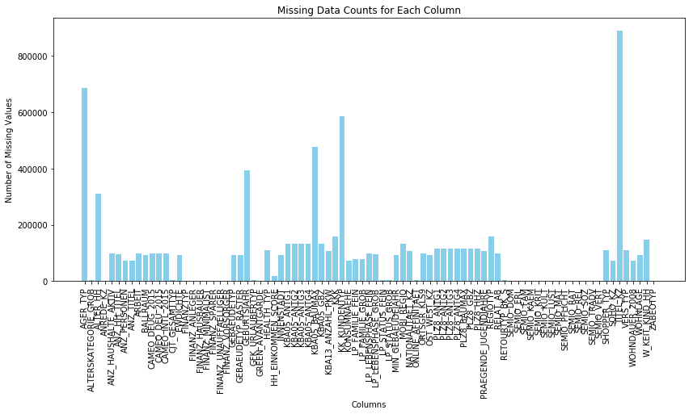

```python
# Perform an assessment of how much missing data there is in each column of the
# dataset.
missData = genDemo.isna().sum()

plt.figure(figsize=(14,6))
plt.bar(missData.index, missData.values, color='skyblue')
plt.xlabel('Columns')
plt.ylabel('Number of Missing Values')
plt.title('Missing Data Counts for Each Column')
plt.xticks(rotation=90)
plt.show

outlierCols = missData[missData > 200000]

print("Outlier Columns: ({})".format(len(outlierCols)))
print(outlierCols)
```

We have roughly a million rows in this dataframe, so by making the cutoff at 200,000 we are saying that for a column to be retained we are demanding that 80% or more of the data is real and populated which I believe is a fair metric. Putting the cutoff at 200k means that we are dropping 6 of our 85 columns but at least now we know that the columns we have contain lots of useful information.

```python
genDemoCut = genDemo.drop(outlierCols.index, axis=1)
```

#### Discussion 1.1.2: Assess Missing Data in Each Column

These columns are: AGER_TYP, GEBURTSJAHR, TITEL_KZ, ALTER_HH, KK_KUNDENTYP, KBA05_BAUMAX

In general the number of columns that were missing data grew significantly after just looking for nan values vs using the featSumm dataframe to change known values to nan. The column "KK_KUNDENTYP" was mostly full of nan values from the get go whereas the other columns all increased significantly after going through that cleaning step.

#### Step 1.1.3: Assess Missing Data in Each Row

Now, you'll perform a similar assessment for the rows of the dataset. How much data is missing in each row? As with the columns, you should see some groups of points that have a very different numbers of missing values. Divide the data into two subsets: one for data points that are above some threshold for missing values, and a second subset for points below that threshold.

In order to know what to do with the outlier rows, we should see if the distribution of data values on columns that are not missing data (or are missing very little data) are similar or different between the two groups. Select at least five of these columns and compare the distribution of values.

- You can use seaborn's [`countplot()`](https://seaborn.pydata.org/generated/seaborn.countplot.html) function to create a bar chart of code frequencies and matplotlib's [`subplot()`](https://matplotlib.org/api/_as_gen/matplotlib.pyplot.subplot.html) function to put bar charts for the two subplots side by side.
- To reduce repeated code, you might want to write a function that can perform this comparison, taking as one of its arguments a column to be compared.

Depending on what you observe in your comparison, this will have implications on how you approach your conclusions later in the analysis. If the distributions of non-missing features look similar between the data with many missing values and the data with few or no missing values, then we could argue that simply dropping those points from the analysis won't present a major issue. On the other hand, if the data with many missing values looks very different from the data with few or no missing values, then we should make a note on those data as special. We'll revisit these data later on. **Either way, you should continue your analysis for now using just the subset of the data with few or no missing values.**

```python
# Let's first get the number of missing values per row
missing_values_per_row = genDemoCut.isnull().sum(axis=1)
# print(len(missing_values_per_row))
# 891221
```

We have 79 columns in total after removing he 6 columns from above so this would mean that a row with 0 missing values means that all of the information is there and a row with 79 missing values means that all of the information is missing.

I think that a reasonable threshold for the number of missing values per row should be that 90% of the rows are maintained. 90% of 79 is 71.1 so let's round this down to 71 (meaning that slightly less than 90% of the rows will be maintained)

```python
# Write code to divide the data into two subsets based on the number of missing
# values in each row.

threshold = 8 # 79 - 71 = 8

genDemoCut_Rows2Keep = genDemoCut[missing_values_per_row <= threshold]
genDemoCut_Rows2Toss = genDemoCut[missing_values_per_row > threshold]
```

```python
len(genDemoCut_Rows2Keep)
```

```
771701
```

So we originall had 891221 rows and after making our cutoff be 8 (meaning that no more than 8 rows could have missing information) we have reduced our dataframe down to 771701 rows. This means that we have lost roughly 13.4% of our rows after performing this cleaning step.

```python
# Assert statement just so that we can feel confident that our math lined up
assert len(genDemoCut_Rows2Toss) + len(genDemoCut_Rows2Keep) == len(genDemoCut)
```

```python
# Compare the distribution of values for at least five columns where there are
# no or few missing values, between the two subsets.

def compare_column_dist(column_name):
    plt.figure(figsize=(10,6))

    # Plot data frame with the rows that were kept
    plt.subplot(1,2,1)
    sns.countplot(data=genDemoCut_Rows2Keep,
                  x=column_name)
    plt.title(f'Distribution in Rows with <= {threshold} Missing Values')

    # Plot the data frame with the rows that we are discarding
    plt.subplot(1,2,2)
    sns.countplot(data=genDemoCut_Rows2Toss,
                  x=column_name)
    plt.title(f'Distribution in Rows with > {threshold} Missing Values')

    plt.show()
```

```python
# Use this to figure out what columns have less than 2 missing values in the column
# I took 5 of these columns at random to use for this assessment
# goodCols = missData[missData < 2]
# goodCols
```

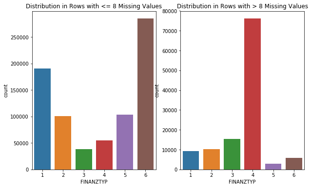

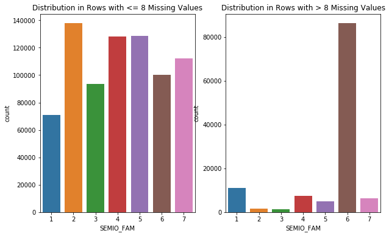

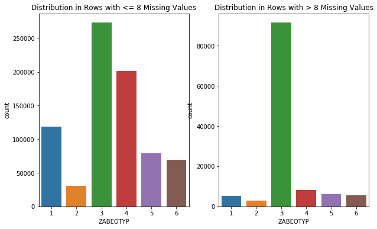

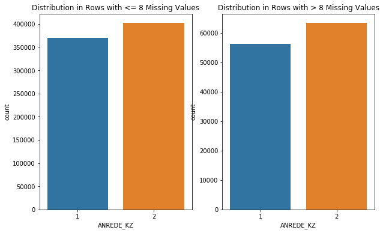

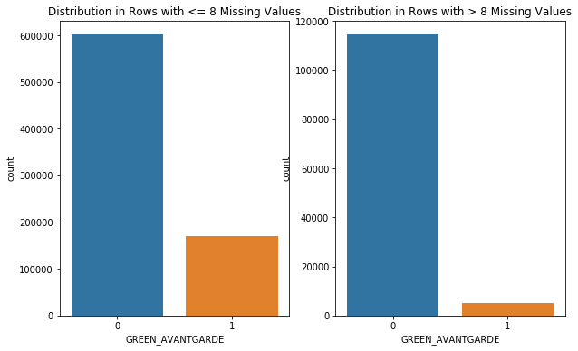

```python
cols2Compare = ['FINANZTYP', 'SEMIO_FAM', 'ZABEOTYP', 'ANREDE_KZ', 'GREEN_AVANTGARDE']

for column in cols2Compare:
    compare_column_dist(column)
```

### Step 1.2: Select and Re-Encode Features

Checking for missing data isn't the only way in which you can prepare a dataset for analysis. Since the unsupervised learning techniques to be used will only work on data that is encoded numerically, you need to make a few encoding changes or additional assumptions to be able to make progress. In addition, while almost all of the values in the dataset are encoded using numbers, not all of them represent numeric values. Check the third column of the feature summary (`feat_info`) for a summary of types of measurement.

- For numeric and interval data, these features can be kept without changes.
- Most of the variables in the dataset are ordinal in nature. While ordinal values may technically be non-linear in spacing, make the simplifying assumption that the ordinal variables can be treated as being interval in nature (that is, kept without any changes).
- Special handling may be necessary for the remaining two variable types: categorical, and 'mixed'.

In the first two parts of this sub-step, you will perform an investigation of the categorical and mixed-type features and make a decision on each of them, whether you will keep, drop, or re-encode each. Then, in the last part, you will create a new data frame with only the selected and engineered columns.

Data wrangling is often the trickiest part of the data analysis process, and there's a lot of it to be done here. But stick with it: once you're done with this step, you'll be ready to get to the machine learning parts of the project!

```python
# How many features are there of each data type?
for type_, type_df in featSumm.groupby('type'):
    print("Datatype {} is found in {} features.".format(type_, len(type_df)))
```

```
Datatype categorical is found in 21 features.
Datatype interval is found in 1 features.
Datatype mixed is found in 7 features.
Datatype numeric is found in 7 features.
Datatype ordinal is found in 49 features.
```

#### Step 1.2.1: Re-Encode Categorical Features

For categorical data, you would ordinarily need to encode the levels as dummy variables. Depending on the number of categories, perform one of the following:

- For binary (two-level) categoricals that take numeric values, you can keep them without needing to do anything.
- There is one binary variable that takes on non-numeric values. For this one, you need to re-encode the values as numbers or create a dummy variable.
- For multi-level categoricals (three or more values), you can choose to encode the values using multiple dummy variables (e.g. via [OneHotEncoder](http://scikit-learn.org/stable/modules/generated/sklearn.preprocessing.OneHotEncoder.html)), or (to keep things straightforward) just drop them from the analysis. As always, document your choices in the Discussion section.

```python
# Assess categorical variables: which are binary, which are multi-level, and
# which one needs to be re-encoded?
def encode_categorical_data(df, categorical_cols, method="drop"):
    """
    Encode categorical data in a DataFrame with special handling for binary categoricals.

    ::Parameters::
        - df: pandas DataFrame
              The input DataFrame containing the data.
        - categorical_cols: list of str
              A list of column names that contain categorical data.
        - method: str, optional (default="drop")
              The method to encode the data. Options: "drop" or "one-hot".

    ::Returns::
        - encoded_df: pandas DataFrame
              The DataFrame with encoded or dropped categorical columns.
    """

    if method not in ["drop", "one-hot"]:
        raise ValueError("Method must be 'drop' or 'one-hot'.")

    for col in categorical_cols:
        if col in df.columns:
            # The length of unique values is 2 so this means that it is either numeric or non-numeric
            # and these are handled as such
            if len(df[col].unique()) == 2:
                if pd.api.types.is_numeric_dtype(df[col]):
                    continue  # Binary numeric variable, no action needed
                else:
                    le = LabelEncoder()
                    df[col] = le.fit_transform(df[col])
            # If the user chose to perform one hot encoding then we need to honor that
            elif method == "one-hot":
                # For multi-level categoricals, perform one-hot encoding
                dummies = pd.get_dummies(df[col], drop_first=True)  # Use drop_first=True to drop the first category
                df = pd.concat([df, dummies], axis=1)
                df = df.drop(columns=col)
            # If the user has requested "drop" then our job is very easy
            else:
                df = df.drop(columns=col)
        else:
            print("Column {} was not found in the reduced genDemo dataframe".format(col))
            print("This is actually okay as it is possible that this column was dropped from our previous cleaning steps")


    return df
```

```python
# Re-encode categorical variable(s) to be kept in the analysis.
categorical_attributes = featSumm[featSumm['type'] == 'categorical']['attribute'].tolist()
# categorical_attributes
```

```python
genDemoCut_Rows2Keep_CatAddressed = encode_categorical_data(genDemoCut_Rows2Keep, categorical_attributes, 'drop')
```

```
Column AGER_TYP was not found in the reduced genDemo dataframe
This is actually okay as it is possible that this column was dropped from our previous cleaning steps
Column TITEL_KZ was not found in the reduced genDemo dataframe
This is actually okay as it is possible that this column was dropped from our previous cleaning steps
Column KK_KUNDENTYP was not found in the reduced genDemo dataframe
This is actually okay as it is possible that this column was dropped from our previous cleaning steps
```

```python
genDemoCut_Rows2Keep_CatAddressed.shape
```

```
(771701, 65)
```

UPDATE: Since we are going to apply this to the customer data at the end, I am actually going to "drop" the columns that contain nan. So this left us with 65 columns at the end of the day!

#### Discussion 1.2.1: Re-Encode Categorical Features

I wrote a function that allows the user to either simply drop the categorical features it encounters or perform one hot encoding. In the function it looks to handle the binary categoricals first and foremost as it was requested that these were kept no matter what. It looks to see if the unique values are numerics and if so it keeps it, otherwise it performs label encoding on. It is interesting to note that of the 21 categorical features (columns), 3 of these columns were already dropped from our previous cleaning steps: 'AGER_TYP', 'TITEL_KZ', and 'KK_KUNDENTYP' which is actually okay as we did see these in the previous analysis as columns that were missing lots of data.

#### Step 1.2.2: Engineer Mixed-Type Features

There are a handful of features that are marked as "mixed" in the feature summary that require special treatment in order to be included in the analysis. There are two in particular that deserve attention; the handling of the rest are up to your own choices:

- "PRAEGENDE_JUGENDJAHRE" combines information on three dimensions: generation by decade, movement (mainstream vs. avantgarde), and nation (east vs. west). While there aren't enough levels to disentangle east from west, you should create two new variables to capture the other two dimensions: an interval-type variable for decade, and a binary variable for movement.
- "CAMEO_INTL_2015" combines information on two axes: wealth and life stage. Break up the two-digit codes by their 'tens'-place and 'ones'-place digits into two new ordinal variables (which, for the purposes of this project, is equivalent to just treating them as their raw numeric values).
- If you decide to keep or engineer new features around the other mixed-type features, make sure you note your steps in the Discussion section.

Be sure to check `Data_Dictionary.md` for the details needed to finish these tasks.

```python
# display(Markdown("Data_Dictionary.md"))
```

```python
mixed_attributes = featSumm[featSumm['type'] == 'mixed']['attribute'].tolist()
# mixed_attributes
```

```python
# Investigate "PRAEGENDE_JUGENDJAHRE" and engineer two new variables.
# This creates a new column which divides us up into "mainstream" vs "avantarde"
genDemoCut_Rows2Keep_CatAddressed['PRAEGENDE_JUGENDJAHRE_MAINSTREAM'] = genDemoCut_Rows2Keep_CatAddressed['PRAEGENDE_JUGENDJAHRE']
genDemoCut_Rows2Keep_CatAddressed['PRAEGENDE_JUGENDJAHRE_MAINSTREAM'] = genDemoCut_Rows2Keep_CatAddressed['PRAEGENDE_JUGENDJAHRE_MAINSTREAM'].replace(to_replace=[1,3,5,8,10,12,14], value=True)
genDemoCut_Rows2Keep_CatAddressed['PRAEGENDE_JUGENDJAHRE_MAINSTREAM'] = genDemoCut_Rows2Keep_CatAddressed['PRAEGENDE_JUGENDJAHRE_MAINSTREAM'].replace(to_replace=[2,4,6,7,9,11,13,15], value=False)

# This turns the original column into housing decade data
genDemoCut_Rows2Keep_CatAddressed['PRAEGENDE_JUGENDJAHRE'] = genDemoCut_Rows2Keep_CatAddressed['PRAEGENDE_JUGENDJAHRE'].replace(to_replace=[1,2], value=40)
genDemoCut_Rows2Keep_CatAddressed['PRAEGENDE_JUGENDJAHRE'] = genDemoCut_Rows2Keep_CatAddressed['PRAEGENDE_JUGENDJAHRE'].replace(to_replace=[3,4], value=50)
genDemoCut_Rows2Keep_CatAddressed['PRAEGENDE_JUGENDJAHRE'] = genDemoCut_Rows2Keep_CatAddressed['PRAEGENDE_JUGENDJAHRE'].replace(to_replace=[5,6,7], value=60)
genDemoCut_Rows2Keep_CatAddressed['PRAEGENDE_JUGENDJAHRE'] = genDemoCut_Rows2Keep_CatAddressed['PRAEGENDE_JUGENDJAHRE'].replace(to_replace=[8,9], value=70)
genDemoCut_Rows2Keep_CatAddressed['PRAEGENDE_JUGENDJAHRE'] = genDemoCut_Rows2Keep_CatAddressed['PRAEGENDE_JUGENDJAHRE'].replace(to_replace=[10,11,12,13], value=80)
genDemoCut_Rows2Keep_CatAddressed['PRAEGENDE_JUGENDJAHRE'] = genDemoCut_Rows2Keep_CatAddressed['PRAEGENDE_JUGENDJAHRE'].replace(to_replace=[14,15], value=90)
```

```python
# Investigate "CAMEO_INTL_2015" and engineer two new variables.

genDemoCut_Rows2Keep_CatAddressed['CAMEO_INTL_2015'] = pd.to_numeric(genDemoCut_Rows2Keep_CatAddressed['CAMEO_INTL_2015'])

genDemoCut_Rows2Keep_CatAddressed['CAMEO_INTL_2015_TENS'] = genDemoCut_Rows2Keep_CatAddressed['CAMEO_INTL_2015'] // 10
genDemoCut_Rows2Keep_CatAddressed['CAMEO_INTL_2015_ONES'] = genDemoCut_Rows2Keep_CatAddressed['CAMEO_INTL_2015'] % 10
genDemoCut_Rows2Keep_CatAddressed.drop(columns=['CAMEO_INTL_2015'], inplace=True)
```

#### Discussion 1.2.2: Engineer Mixed-Type Features

This section was a bit of a struggle, but by reading through the documentation I was able to figure out how to break up the 'PRAEGENDE_JUGENDJAHRE' column to handle the encoded information that we were after. I was also able to turn the string values in the column 'CAMEO_INTL_2015' into numerics which allowed for some simple math to be used that helped us quickly transform the TENS and ONES places into new features that we were after.

#### Step 1.2.3: Complete Feature Selection

In order to finish this step up, you need to make sure that your data frame now only has the columns that you want to keep. To summarize, the dataframe should consist of the following:

- All numeric, interval, and ordinal type columns from the original dataset.
- Binary categorical features (all numerically-encoded).
- Engineered features from other multi-level categorical features and mixed features.

Make sure that for any new columns that you have engineered, that you've excluded the original columns from the final dataset. Otherwise, their values will interfere with the analysis later on the project. For example, you should not keep "PRAEGENDE_JUGENDJAHRE", since its values won't be useful for the algorithm: only the values derived from it in the engineered features you created should be retained. As a reminder, your data should only be from **the subset with few or no missing values**.

```python
# Uncomment this to manually look through each columns datatype -- it looks like everything is numeric!
# The column "PRAEGENDE_JUGENDJAHRE_MAINSTREAM" is of type "object" but that is because it took values of "True" and "False"

#genDemoCut_Rows2Keep_CatAddressed.dtypes
```

```python
# If there are other re-engineering tasks you need to perform, make sure you
# take care of them here. (Dealing with missing data will come in step 2.1.)
```

```python
# Do whatever you need to in order to ensure that the dataframe only contains
# the columns that should be passed to the algorithm functions.
```

Everything should be transformed and good to go if the above steps were all followed correctly. Going to leave this blank for now but I can come back to this section later if anything is wrong and needs to be cleaned up.

### Step 1.3: Create a Cleaning Function

Even though you've finished cleaning up the general population demographics data, it's important to look ahead to the future and realize that you'll need to perform the same cleaning steps on the customer demographics data. In this substep, complete the function below to execute the main feature selection, encoding, and re-engineering steps you performed above. Then, when it comes to looking at the customer data in Step 3, you can just run this function on that DataFrame to get the trimmed dataset in a single step.

```python
def clean_data(df, method='drop'):
    """
    Perform feature trimming, re-encoding, and engineering for demographics
    data

    INPUT: Demographics DataFrame
    OUTPUT: Trimmed and cleaned demographics DataFrame
    """

    # Step 1: Address the missing values in the columns
    def extract_missing_values(missing_str):
    # Use a regular expression to find all numeric values in the string
        missing_values = re.findall(r"-?\d+", missing_str)
        return [int(value) for value in missing_values]  # Convert to a list of integers

    for col in df.columns:
        missing_or_unknown_str = featSumm.loc[featSumm['attribute'] == col, 'missing_or_unknown'].iloc[0]

        # Check for the special values "X" or "XX" and replace them with np.nan
        if 'X' in missing_or_unknown_str or 'XX' in missing_or_unknown_str:
            df[col] = df[col].replace({'X': np.nan, 'XX': np.nan})
        else:
            # Extract missing values using the defined function
            missing_or_unknown = extract_missing_values(missing_or_unknown_str)
            df[col] = df[col].apply(lambda x: np.nan if x in missing_or_unknown else x)

    # Step 2: Address the missing values that are above some threshold in each column
    missData = df.isna().sum()
    outlierCols = missData[missData > 200000]
    df = df.drop(outlierCols.index, axis=1)

    # Step 3: Address the missing values in each row
    missing_values_per_row = df.isnull().sum(axis=1)
    threshold = 8 # 79 - 71 = 8
    df = df[missing_values_per_row <= threshold]

    # Step 4: Address the categorical columns
    categorical_attributes = featSumm[featSumm['type'] == 'categorical']['attribute'].tolist()
    df = encode_categorical_data(df, categorical_attributes, method=method)

    # Step 5: Address the mixed columns
    mixed_attributes = featSumm[featSumm['type'] == 'mixed']['attribute'].tolist()
    df['PRAEGENDE_JUGENDJAHRE_MAINSTREAM'] = df['PRAEGENDE_JUGENDJAHRE']
    df['PRAEGENDE_JUGENDJAHRE_MAINSTREAM'] = df['PRAEGENDE_JUGENDJAHRE_MAINSTREAM'].replace(to_replace=[1,3,5,8,10,12,14], value=True)
    df['PRAEGENDE_JUGENDJAHRE_MAINSTREAM'] = df['PRAEGENDE_JUGENDJAHRE_MAINSTREAM'].replace(to_replace=[2,4,6,7,9,11,13,15], value=False)
    df['PRAEGENDE_JUGENDJAHRE'] = df['PRAEGENDE_JUGENDJAHRE'].replace(to_replace=[1,2], value=40)
    df['PRAEGENDE_JUGENDJAHRE'] = df['PRAEGENDE_JUGENDJAHRE'].replace(to_replace=[3,4], value=50)
    df['PRAEGENDE_JUGENDJAHRE'] = df['PRAEGENDE_JUGENDJAHRE'].replace(to_replace=[5,6,7], value=60)
    df['PRAEGENDE_JUGENDJAHRE'] = df['PRAEGENDE_JUGENDJAHRE'].replace(to_replace=[8,9], value=70)
    df['PRAEGENDE_JUGENDJAHRE'] = df['PRAEGENDE_JUGENDJAHRE'].replace(to_replace=[10,11,12,13], value=80)
    df['PRAEGENDE_JUGENDJAHRE'] = df['PRAEGENDE_JUGENDJAHRE'].replace(to_replace=[14,15], value=90)

    df['CAMEO_INTL_2015'] = pd.to_numeric(df['CAMEO_INTL_2015'])
    df['CAMEO_INTL_2015_TENS'] = df['CAMEO_INTL_2015'] // 10
    df['CAMEO_INTL_2015_ONES'] = df['CAMEO_INTL_2015'] % 10
    df.drop(columns=['CAMEO_INTL_2015'], inplace=True)

    return df

    # Put in code here to execute all main cleaning steps:
    # convert missing value codes into NaNs, ...
    # remove selected columns and rows, ...
    # select, re-encode, and engineer column values.
    # Return the cleaned dataframe.
```

## Step 2: Feature Transformation

### Step 2.1: Apply Feature Scaling

Before we apply dimensionality reduction techniques to the data, we need to perform feature scaling so that the principal component vectors are not influenced by the natural differences in scale for features. Starting from this part of the project, you'll want to keep an eye on the [API reference page for sklearn](http://scikit-learn.org/stable/modules/classes.html) to help you navigate to all of the classes and functions that you'll need. In this substep, you'll need to check the following:

- sklearn requires that data not have missing values in order for its estimators to work properly. So, before applying the scaler to your data, make sure that you've cleaned the DataFrame of the remaining missing values. This can be as simple as just removing all data points with missing data, or applying an [Imputer](https://scikit-learn.org/0.16/modules/generated/sklearn.preprocessing.Imputer.html) to replace all missing values. You might also try a more complicated procedure where you temporarily remove missing values in order to compute the scaling parameters before re-introducing those missing values and applying imputation. Think about how much missing data you have and what possible effects each approach might have on your analysis, and justify your decision in the discussion section below.
- For the actual scaling function, a [StandardScaler](http://scikit-learn.org/stable/modules/generated/sklearn.preprocessing.StandardScaler.html) instance is suggested, scaling each feature to mean 0 and standard deviation 1.
- For these classes, you can make use of the `.fit_transform()` method to both fit a procedure to the data as well as apply the transformation to the data at the same time. Don't forget to keep the fit sklearn objects handy, since you'll be applying them to the customer demographics data towards the end of the project.

```python
# Let's just verify that our function from above works by using it

newDf = genDemoCut_Rows2Keep_CatAddressed
```

```python
# If you've not yet cleaned the dataset of all NaN values, then investigate and
# do that now.

# We can see here that a lot of columns still contain nan values...
# We have the option to either drop them altogether or impute or use a creative measure.
# Let's try to impute the values!

# UPDATE: The kernel keeps crashing so I am going to try simply dropping those columns with 'NaN' values
# as this will reduce the size of the data and maybe make it so that the kernel does not crash...

# newDf.isna().sum()
```

```python
# IMPUTER ATTEMPT
# imputer = SimpleImputer(strategy='mean')
# newDfImp = imputer.fit_transform(newDf)
# newDfImp = pd.DataFrame(newDfImp, columns=newDf.columns)
```

```python
# DROP ATTEMPT
newDfDrop = newDf.dropna()
```

```python
# Let's verify that there are no more missing values after imputation!

# newDfImp.isna().sum()
# newDfDrop.isna().sum()
```

```python
# Apply feature scaling to the general population demographics data.
# The output of this is an ndarray which is fine for our analysis but if we wanted to turn it back into a dataframe we could
# with a similiar strategy that we used above

scaler = StandardScaler()

newDfDropScal = scaler.fit_transform(newDfDrop)
```

### Discussion 2.1: Apply Feature Scaling

For the feature scaling section I initally chose to use a simple imputer with a mean strategy in order to preserve as much data as possible. It did seem like a good number of features (maybe around 3/4 of them?) all had 0 'NaN' values so it would also be acceptable to simply drop those columns but this technique seems reasonable. The kernel kept crashing so I did have to change my strategy over to just dropping the rows that contained any 'NaN' values.

After that I applied a Standard Scaler with the default parameters in order to make it so that PCA works appropraitely.

### Step 2.2: Perform Dimensionality Reduction

On your scaled data, you are now ready to apply dimensionality reduction techniques.

- Use sklearn's [PCA](http://scikit-learn.org/stable/modules/generated/sklearn.decomposition.PCA.html) class to apply principal component analysis on the data, thus finding the vectors of maximal variance in the data. To start, you should not set any parameters (so all components are computed) or set a number of components that is at least half the number of features (so there's enough features to see the general trend in variability).
- Check out the ratio of variance explained by each principal component as well as the cumulative variance explained. Try plotting the cumulative or sequential values using matplotlib's [`plot()`](https://matplotlib.org/api/_as_gen/matplotlib.pyplot.plot.html) function. Based on what you find, select a value for the number of transformed features you'll retain for the clustering part of the project.
- Once you've made a choice for the number of components to keep, make sure you re-fit a PCA instance to perform the decided-on transformation.

```python
# Apply PCA to the data.

# NOTE: The kernel crashes if I set n_components=75 but it does not crash if I set n_components=3
# I am going to try and make n_components as big as possible without having the kernel crash

# The kernel was able to successfully make run when n_components=20
# The kernel failed when n_components=30

# The kernel is successful when n_components=25
# Going to set that as the value for now and will back off if I encounter any other kernel crashing issues.

# Backing off to n_components = 23

n_components = 23

pca = PCA(n_components=n_components)

X_pca = pca.fit_transform(newDfDropScal)
```

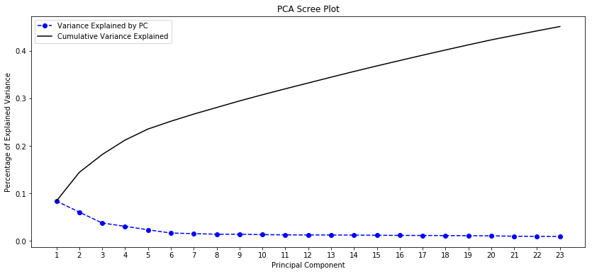

```python
# Investigate the variance accounted for by each principal component.

PCs = [i+1 for i in range(n_components)]

dfCumul = pd.DataFrame({'perc_explained_var_ratio': pca.explained_variance_ratio_,
                        'PC': PCs})

dfCumul['cumulative_variance'] = dfCumul['perc_explained_var_ratio'].cumsum()

plt.figure(figsize=(14,6))
plt.plot(dfCumul['PC'],
         dfCumul['perc_explained_var_ratio'],
         color='b',
         marker='o',
         linestyle='--',
         label='Variance Explained by PC')
plt.xlabel('Principal Component')
plt.ylabel('Percentage of Explained Variance')
plt.title('PCA Scree Plot')

plt.plot(dfCumul['PC'],
         dfCumul['cumulative_variance'],
         color='k',
         label='Cumulative Variance Explained')
plt.xticks(dfCumul['PC'])
plt.legend()
plt.show()
```

```python
# Re-apply PCA to the data while selecting for number of components to retain.
# It looks like there is an elbow point around 3 principal components

n_components = 3

pca = PCA(n_components=n_components)

X_pca = pca.fit_transform(newDfDropScal)
```

### Discussion 2.2: Perform Dimensionality Reduction

This section suffered from the kernel dying so some updates had to be made. I first added as many pricipal components as I could without dealing with the dying kernel which for me was 23 PC's. From there I made a scree plot looking at the explained variance of each principal component and found an elbow point around the 3 component mark. So I reran the PCA process but this time set the number of components to be 3.

### Step 2.3: Interpret Principal Components

Now that we have our transformed principal components, it's a nice idea to check out the weight of each variable on the first few components to see if they can be interpreted in some fashion.

As a reminder, each principal component is a unit vector that points in the direction of highest variance (after accounting for the variance captured by earlier principal components). The further a weight is from zero, the more the principal component is in the direction of the corresponding feature. If two features have large weights of the same sign (both positive or both negative), then increases in one tend expect to be associated with increases in the other. To contrast, features with different signs can be expected to show a negative correlation: increases in one variable should result in a decrease in the other.

- To investigate the features, you should map each weight to their corresponding feature name, then sort the features according to weight. The most interesting features for each principal component, then, will be those at the beginning and end of the sorted list. Use the data dictionary document to help you understand these most prominent features, their relationships, and what a positive or negative value on the principal component might indicate.
- You should investigate and interpret feature associations from the first three principal components in this substep. To help facilitate this, you should write a function that you can call at any time to print the sorted list of feature weights, for the *i*-th principal component. This might come in handy in the next step of the project, when you interpret the tendencies of the discovered clusters.

```python
def interpret_pca_components(pca, feature_names, n_components=3, print_all=False):
    # Check if the number of components requested is greater than the actual number of components in the PCA object
    if n_components > pca.n_components_:
        print(f"Error: The PCA object has only {pca.n_components_} components.")
        return

    # Loop through the desired number of components
    for i in range(n_components):
        component = pca.components_[i]
        feature_weights = zip(feature_names, component)

        # Sort the features by their weight in the component
        sorted_features = sorted(feature_weights, key=lambda x: x[1], reverse=True)

        # Display the sorted features for the i-th component
        print(f"Principal Component {i + 1} Features:")
        if print_all == True:
            for feature, weight in sorted_features:
                print(f"{feature}: {weight}")
            print("\n")
        else:
            print("Top 5 Features and Weights:")
            for feature, weight in sorted_features[:5]:
                print(f"{feature}: {weight}")
            print("=============================")
            print("Bottom 5 Features and Weights")
            for feature, weight in sorted_features[-5:]:
                print(f"{feature}: {weight}")
            print("=============================")
            print("=============================")
```

```python
# Map weights for the first principal component to corresponding feature names
# and then print the linked values, sorted by weight.
# HINT: Try defining a function here or in a new cell that you can reuse in the
# other cells.

# Prints all 3 PC's

interpret_pca_components(pca, newDf.columns)
```

```
Principal Component 1 Features:
Top 5 Features and Weights:
PLZ8_ANTG3: 0.18510009405011893
CAMEO_INTL_2015_TENS: 0.1828749939268591
PLZ8_ANTG4: 0.1795938795656397
HH_EINKOMMEN_SCORE: 0.1793329726778346
PLZ8_BAUMAX: 0.17697327460757242
=============================
Bottom 5 Features and Weights
KBA05_GBZ: -0.18163533118277597
PLZ8_ANTG1: -0.1876518203427853
FINANZ_MINIMALIST: -0.1916926882641988
KBA05_ANTG1: -0.1933512259852692
MOBI_REGIO: -0.20555150386397616
=============================
=============================
Principal Component 2 Features:
Top 5 Features and Weights:
ALTERSKATEGORIE_GROB: 0.2329055576068127
FINANZ_VORSORGER: 0.21383738158927643
3: 0.20157024703982038
SEMIO_ERL: 0.18632544067066004
SEMIO_LUST: 0.16243884618004087
=============================
Bottom 5 Features and Weights
FINANZ_UNAUFFAELLIGER: -0.21063946302688907
SEMIO_PFLICHT: -0.21369700714124512
FINANZ_SPARER: -0.22009215175075814
SEMIO_REL: -0.22204328788331637
PRAEGENDE_JUGENDJAHRE: -0.23571164679944007
=============================
=============================
Principal Component 3 Features:
Top 5 Features and Weights:
SEMIO_VERT: 0.3259589592712953
SEMIO_SOZ: 0.25755098603286086
SEMIO_FAM: 0.25664529625893523
SEMIO_KULT: 0.24272173811848102
5: 0.1462045356537751
=============================
Bottom 5 Features and Weights
SEMIO_ERL: -0.19681370817487678
SEMIO_KRIT: -0.26076323861984396
SEMIO_DOM: -0.2770230368749873
SEMIO_KAEM: -0.3126083832493891
ANREDE_KZ: -0.3438855148128164
=============================
=============================
```

```python
# display(Markdown("Data_Dictionary.md"))
```

### Discussion 2.3: Interpret Principal Components

The first principal component seems to positivly correlate to the number and wealth of households in the general population, and more specifically in the PLZ8 region. It negatively correlates to the smaller (1-2 family homes) in the microcell and PLZ8 region.

The second principal component seems to positively correlate to some kind of age metric within the general population. It negatively correlates to the typology and movement of youth in the region.

The third principal component seems to positively correlate to "SEMIO_XYZ" features. Lookking through the documentation I could not find exactly what these represented but this prefix "SEMIO" was found in 4 of the top 5 features. It negatively correlates to the 4 more features that start with "SEMIO". Additional research would need to be performed in order to gather what this relates to exactly.

## Step 3: Clustering

### Step 3.1: Apply Clustering to General Population

You've assessed and cleaned the demographics data, then scaled and transformed them. Now, it's time to see how the data clusters in the principal components space. In this substep, you will apply k-means clustering to the dataset and use the average within-cluster distances from each point to their assigned cluster's centroid to decide on a number of clusters to keep.

- Use sklearn's KMeans class to perform k-means clustering on the PCA-transformed data.
- Then, compute the average difference from each point to its assigned cluster's center. **Hint**: The KMeans object's `.score()` method might be useful here, but note that in sklearn, scores tend to be defined so that larger is better. Try applying it to a small, toy dataset, or use an internet search to help your understanding.
- Perform the above two steps for a number of different cluster counts. You can then see how the average distance decreases with an increasing number of clusters. However, each additional cluster provides a smaller net benefit. Use this fact to select a final number of clusters in which to group the data. **Warning**: because of the large size of the dataset, it can take a long time for the algorithm to resolve. The more clusters to fit, the longer the algorithm will take. You should test for cluster counts through at least 10 clusters to get the full picture, but you shouldn't need to test for a number of clusters above about 30.
- Once you've selected a final number of clusters to use, re-fit a KMeans instance to perform the clustering operation. Make sure that you also obtain the cluster assignments for the general demographics data, since you'll be using them in the final Step 3.3.

```python
def KMeans_ScreePlot(X_pca, max_clusters=20, RANDOM_STATE=0):

    upperBound = max_clusters+1
    scores = []
    centers = list(range(1,upperBound))

    for cluster in range(1,upperBound):
        kmeans = KMeans(n_clusters=cluster,
                        random_state=RANDOM_STATE)
        kmeans.fit(X_pca)
        scores.append(np.abs(kmeans.score(X_pca)))

    plt.figure(figsize=(12,6))
    plt.plot(centers, scores, linestyle='--', marker='o', color='b')
    plt.xlabel('# of Clusters')
    plt.ylabel('Sum of Square Errors (SSE)')
    plt.title('Elbow Plot: SSE vs # of Clusters')
    plt.xticks(centers)

    return None
```

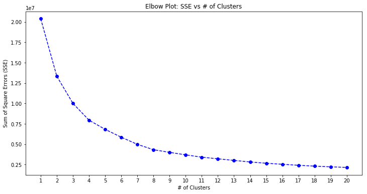

```python
# This cell takes quite a long time to run...
# KMeans_ScreePlot(X_pca)
```

The elbow point looks to happen around 3 or 4 clusters. Going to go with 4 for this analysis.

```python
# Re-fit the k-means model with the selected number of clusters and obtain
# cluster predictions for the general population demographics data.

kmeans = KMeans(n_clusters=4)
model = kmeans.fit(X_pca)
labels = model.predict(X_pca)
```

### Discussion 3.1: Apply Clustering to General Population

It took a VERY long time to run the above elbow plot so only uncomment and run that cell if you have maybe 45 mins available. It looks like the elbow plot show that about 3 to 4 clusters would be the appropriate number of clusters for this analysis so I went with 4 and reran the KMeans model with that parameter.

### Step 3.2: Apply All Steps to the Customer Data

Now that you have clusters and cluster centers for the general population, it's time to see how the customer data maps on to those clusters. Take care to not confuse this for re-fitting all of the models to the customer data. Instead, you're going to use the fits from the general population to clean, transform, and cluster the customer data. In the last step of the project, you will interpret how the general population fits apply to the customer data.

- Don't forget when loading in the customers data, that it is semicolon (`;`) delimited.
- Apply the same feature wrangling, selection, and engineering steps to the customer demographics using the `clean_data()` function you created earlier. (You can assume that the customer demographics data has similar meaning behind missing data patterns as the general demographics data.)
- Use the sklearn objects from the general demographics data, and apply their transformations to the customers data. That is, you should not be using a `.fit()` or `.fit_transform()` method to re-fit the old objects, nor should you be creating new sklearn objects! Carry the data through the feature scaling, PCA, and clustering steps, obtaining cluster assignments for all of the data in the customer demographics data.

```python
# Load in the customer demographics data.
customers = pd.read_csv("Udacity_CUSTOMERS_Subset.csv",
                        delimiter=";")
```

```python
# Apply preprocessing, feature transformation, and clustering from the general
# demographics onto the customer data, obtaining cluster predictions for the
# customer demographics data.

# Apply the clean_data function
custDemo = clean_data(customers)
```

```python
# Since our scaler object was fit on the general population which had 67 columns
# we need to ensure that our customer data has those same 67 columns!
columns_to_keep = newDfDrop.columns
custDemo_reduced = custDemo[columns_to_keep]
```

```python
# And we see here that we have 67 columns! Fantastic!
print(custDemo_reduced.shape)
```

```
(128298, 67)
```

```python
# But now we have to check and see if these values have any nan's
# Which it looks like they do...
custDemo_reduced.isna().sum()
```

```
ALTERSKATEGORIE_GROB                 171
ANREDE_KZ                              0
FINANZ_MINIMALIST                      0
FINANZ_SPARER                          0
FINANZ_VORSORGER                       0
FINANZ_ANLEGER                         0
FINANZ_UNAUFFAELLIGER                  0
FINANZ_HAUSBAUER                       0
GREEN_AVANTGARDE                       0
HEALTH_TYP                          1511
LP_LEBENSPHASE_FEIN                 2697
LP_LEBENSPHASE_GROB                 2661
PRAEGENDE_JUGENDJAHRE                362
RETOURTYP_BK_S                         0
SEMIO_SOZ                              0
SEMIO_FAM                              0
SEMIO_REL                              0
SEMIO_MAT                              0
SEMIO_VERT                             0
SEMIO_LUST                             0
SEMIO_ERL                              0
SEMIO_KULT                             0
SEMIO_RAT                              0
SEMIO_KRIT                             0
SEMIO_DOM                              0
SEMIO_KAEM                             0
SEMIO_PFLICHT                          0
SEMIO_TRADV                            0
SOHO_KZ                                0
ANZ_PERSONEN                           0
ANZ_TITEL                              0
HH_EINKOMMEN_SCORE                     0
W_KEIT_KIND_HH                      4082
WOHNDAUER_2008                         0
ANZ_HAUSHALTE_AKTIV                  495
ANZ_HH_TITEL                         333
KONSUMNAEHE                            5
MIN_GEBAEUDEJAHR                       0
OST_WEST_KZ                            0
WOHNLAGE                               0
```

[output cut: 13 more lines]

```
KBA13_ANZAHL_PKW                      42
PLZ8_ANTG1                            36
PLZ8_ANTG2                            36
PLZ8_ANTG3                            36
PLZ8_ANTG4                            36
PLZ8_BAUMAX                           36
PLZ8_HHZ                              36
PLZ8_GBZ                              36
ARBEIT                               499
ORTSGR_KLS9                          482
RELAT_AB                             499
PRAEGENDE_JUGENDJAHRE_MAINSTREAM     362
CAMEO_INTL_2015_TENS                 180
CAMEO_INTL_2015_ONES                 180
dtype: int64
```

```python
# We are going to impute the mean value into these empty columns using imputation
# Note that we are imputing the mean value from the GENERAL POPULATION here!
mean_values = newDfDrop.mean()

for column in custDemo_reduced.columns:
    custDemo_reduced[column].fillna(mean_values[column], inplace=True)
```

```python
# And let's just verify that there are no more nan values
custDemo_reduced.isna().sum()
```

```
ALTERSKATEGORIE_GROB                0
ANREDE_KZ                           0
FINANZ_MINIMALIST                   0
FINANZ_SPARER                       0
FINANZ_VORSORGER                    0
FINANZ_ANLEGER                      0
FINANZ_UNAUFFAELLIGER               0
FINANZ_HAUSBAUER                    0
GREEN_AVANTGARDE                    0
HEALTH_TYP                          0
LP_LEBENSPHASE_FEIN                 0
LP_LEBENSPHASE_GROB                 0
PRAEGENDE_JUGENDJAHRE               0
RETOURTYP_BK_S                      0
SEMIO_SOZ                           0
SEMIO_FAM                           0
SEMIO_REL                           0
SEMIO_MAT                           0
SEMIO_VERT                          0
SEMIO_LUST                          0
SEMIO_ERL                           0
SEMIO_KULT                          0
SEMIO_RAT                           0
SEMIO_KRIT                          0
SEMIO_DOM                           0
SEMIO_KAEM                          0
SEMIO_PFLICHT                       0
SEMIO_TRADV                         0
SOHO_KZ                             0
ANZ_PERSONEN                        0
ANZ_TITEL                           0
HH_EINKOMMEN_SCORE                  0
W_KEIT_KIND_HH                      0
WOHNDAUER_2008                      0
ANZ_HAUSHALTE_AKTIV                 0
ANZ_HH_TITEL                        0
KONSUMNAEHE                         0
MIN_GEBAEUDEJAHR                    0
OST_WEST_KZ                         0
WOHNLAGE                            0
```

[output cut: 13 more lines]

```
KBA13_ANZAHL_PKW                    0
PLZ8_ANTG1                          0
PLZ8_ANTG2                          0
PLZ8_ANTG3                          0
PLZ8_ANTG4                          0
PLZ8_BAUMAX                         0
PLZ8_HHZ                            0
PLZ8_GBZ                            0
ARBEIT                              0
ORTSGR_KLS9                         0
RELAT_AB                            0
PRAEGENDE_JUGENDJAHRE_MAINSTREAM    0
CAMEO_INTL_2015_TENS                0
CAMEO_INTL_2015_ONES                0
dtype: int64
```

```python
# We are only using TRANSFORM here such that the means and standard deviations from the general pop
# are applied to the customer data

custDemoDropScal = scaler.transform(custDemo_reduced)
```

```python
# Perform PCA on the customer data
# We are TRANSFORMING the customer data with the original PCA object
X_pca_customer = pca.transform(custDemoDropScal)
```

```python
# Perform KMeans on the customer data
# We are finding labels for the X_pca_customer object using the original model we instantiated earlier
labels_customer = model.predict(X_pca_customer)
```

### Step 3.3: Compare Customer Data to Demographics Data

At this point, you have clustered data based on demographics of the general population of Germany, and seen how the customer data for a mail-order sales company maps onto those demographic clusters. In this final substep, you will compare the two cluster distributions to see where the strongest customer base for the company is.

Consider the proportion of persons in each cluster for the general population, and the proportions for the customers. If we think the company's customer base to be universal, then the cluster assignment proportions should be fairly similar between the two. If there are only particular segments of the population that are interested in the company's products, then we should see a mismatch from one to the other. If there is a higher proportion of persons in a cluster for the customer data compared to the general population (e.g. 5% of persons are assigned to a cluster for the general population, but 15% of the customer data is closest to that cluster's centroid) then that suggests the people in that cluster to be a target audience for the company. On the other hand, the proportion of the data in a cluster being larger in the general population than the customer data (e.g. only 2% of customers closest to a population centroid that captures 6% of the data) suggests that group of persons to be outside of the target demographics.

Take a look at the following points in this step:

- Compute the proportion of data points in each cluster for the general population and the customer data. Visualizations will be useful here: both for the individual dataset proportions, but also to visualize the ratios in cluster representation between groups. Seaborn's [`countplot()`](https://seaborn.pydata.org/generated/seaborn.countplot.html) or [`barplot()`](https://seaborn.pydata.org/generated/seaborn.barplot.html) function could be handy.
  - Recall the analysis you performed in step 1.1.3 of the project, where you separated out certain data points from the dataset if they had more than a specified threshold of missing values. If you found that this group was qualitatively different from the main bulk of the data, you should treat this as an additional data cluster in this analysis. Make sure that you account for the number of data points in this subset, for both the general population and customer datasets, when making your computations!
- Which cluster or clusters are overrepresented in the customer dataset compared to the general population? Select at least one such cluster and infer what kind of people might be represented by that cluster. Use the principal component interpretations from step 2.3 or look at additional components to help you make this inference. Alternatively, you can use the `.inverse_transform()` method of the PCA and StandardScaler objects to transform centroids back to the original data space and interpret the retrieved values directly.
- Perform a similar investigation for the underrepresented clusters. Which cluster or clusters are underrepresented in the customer dataset compared to the general population, and what kinds of people are typified by these clusters?

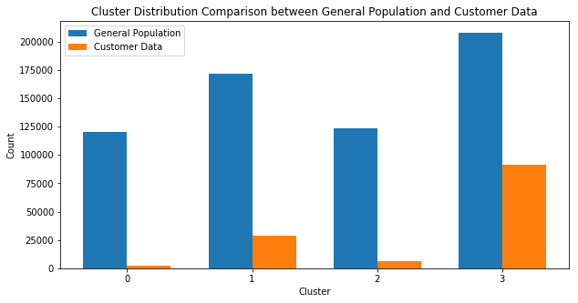

```python
# Compare the proportion of data in each cluster for the customer data to the
# proportion of data in each cluster for the general population.

# Preparing the labels for the gen pop and the customers
general_population_counts = np.bincount(labels)
customer_counts = np.bincount(labels_customer)

# We have 4 clusters
cluster_numbers = list(range(4))

# Some matplotlib things
bar_width = 0.35
fig, ax = plt.subplots(figsize=(10, 5))

bar1 = ax.bar(cluster_numbers,
              general_population_counts,
              bar_width,
              label='General Population')

bar2 = ax.bar(np.array(cluster_numbers) + bar_width,
              customer_counts,
              bar_width,
              label='Customer Data')

ax.set_xlabel('Cluster')
ax.set_ylabel('Count')
ax.set_title('Cluster Distribution Comparison between General Population and Customer Data')
ax.set_xticks(np.array(cluster_numbers) + bar_width / 2)
ax.set_xticklabels(cluster_numbers)
ax.legend()
plt.show()
```

```python
K = 4

total_data_points = len(labels)
gen_pop_cluster_proportions = [np.sum(labels == cluster) / total_data_points for cluster in range(K)]

total_data_points_cust = len(labels_customer)
customer_cluster_proportions = [np.sum(labels_customer == cluster) / total_data_points_cust for cluster in range(K)]

print(gen_pop_cluster_proportions)
print(customer_cluster_proportions)
```

```
[0.19325940414852802, 0.27540520114439937, 0.19789348356650818, 0.33344191114056443]
[0.018332320067343217, 0.2220377558496625, 0.04827822725217852, 0.7113516968308158]
```

We can see the distributions of the general population in blue and the distributions of the customer data in orange. We can see that for cluster 3 there are significantly more customers than the proportions would lead us to believe meaning that we should target these customers in this cluster!

Clusters 0 and 2 however do not seem to be target audiences for our company as the ratio of people in the general population is far greater than the ratio of people in the customer dataset.

Cluster 1 appears to be roughly equivilant to the general population.

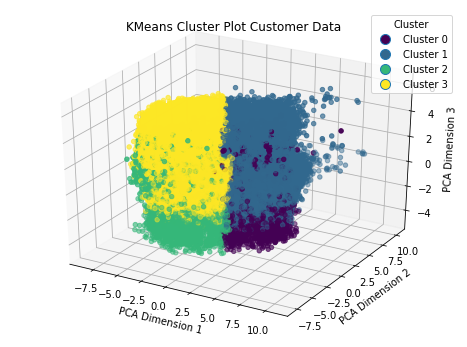

```python
plt.figure(figsize=(8,6))
ax = plt.axes(projection='3d')
ax.grid()
scatter = ax.scatter(X_pca_customer[:,0],
                     X_pca_customer[:,1],
                     X_pca_customer[:,2],
                     c=labels_customer)
ax.set_title("KMeans Cluster Plot Customer Data")
ax.set_xlabel('PCA Dimension 1')
ax.set_ylabel('PCA Dimension 2')
ax.set_zlabel('PCA Dimension 3')

unique_labels = set(labels_customer)
legend_handles = []

for label in unique_labels:
    legend_handles.append(plt.Line2D([0], [0], linestyle='', marker='o', markersize=10, markerfacecolor=scatter.to_rgba(label), label=f'Cluster {label}'))

plt.legend(handles=legend_handles, title="Cluster")

plt.show()
```

We can see that in cluster 3 (where the proportion of people in the customer dataset is far higher than the general population) that these people are strongly negatively associated with PCA dim 1, mildly negatively associated with PCA dim 2, and strongly positively associated with PCA dim 3. Looking at our effort in section 2.3 this would lead us to believe that the type of people that are popular with our company are: strongly correlated with the "SEMIO" features from PCA 3 and are from smaller (1-2) family homes in the microcell/PLZ8 region. They seem to be from the mean age as PCA dimension 2 appears to line up the centroid of this cluster to approximately 0.

### Discussion 3.3: Compare Customer Data to Demographics Data

Overall it does seem like we can make judgements based on which type of customers are popular with our company and which types of customers are unpopular with our company. By using the general population as a kind of litmus test for ourselves we were able to augment our data in the customer dataset to meet the trends of the general population which I belive helps to stengthen our final analysis.

> Congratulations on making it this far in the project! Before you finish, make sure to check through the entire notebook from top to bottom to make sure that your analysis follows a logical flow and all of your findings are documented in **Discussion** cells. Once you've checked over all of your work, you should export the notebook as an HTML document to submit for evaluation. You can do this from the menu, navigating to **File -> Download as -> HTML (.html)**. You will submit both that document and this notebook for your project submission.